# HR Analytics: Job Change of Data Scientists

# Feature:

-enrollee_id : Unique ID for candidate -city: City code -city_ development _index : Developement index of the city (scaled) -gender: Gender of candidate -relevent_experience: Relevant experience of candidate -enrolled_university: Type of University course enrolled if any -education_level: Education level of candidate -major_discipline :Education major discipline of candidate -experience: Candidate total experience in years -company_size: No of employees in current employer's company -company_type : Type of current employer -last_new_job: Difference in years between previous job and current job -training_hours: training hours completed -target: 0 – Not looking for job change, 1 – Looking for a job change

# Inspiration

*Predict the probability of a candidate will work for the company. *Interpret model(s) such a way that illustrate which features affect candidate decision.

# understand data

```python
#import libraries
import pandas as pd
import numpy as np
import matplotlib.pyplot as plt
import seaborn as sns
import category_encoders as ce
from sklearn.preprocessing import LabelEncoder
import missingno as msno
from sklearn.preprocessing import OrdinalEncoder
from imblearn.over_sampling import SMOTE
```

```python
df = pd.read_csv("aug_train.csv")
```

```python
#display the first rows of the dataset
df.head()
```

|  | enrollee_id | city | city_development_index | gender | relevent_experience | enrolled_university | education_level | major_discipline | experience | company_size | company_type | last_new_job | training_hours | target |
| --- | --- | --- | --- | --- | --- | --- | --- | --- | --- | --- | --- | --- | --- | --- |
| 0 | 8949 | city_103 | 0.920 | Male | Has relevent experience | no_enrollment | Graduate | STEM | >20 | NaN | NaN | 1 | 36 | 1.0 |
| 1 | 29725 | city_40 | 0.776 | Male | No relevent experience | no_enrollment | Graduate | STEM | 15 | 50-99 | Pvt Ltd | >4 | 47 | 0.0 |
| 2 | 11561 | city_21 | 0.624 | NaN | No relevent experience | Full time course | Graduate | STEM | 5 | NaN | NaN | never | 83 | 0.0 |
| 3 | 33241 | city_115 | 0.789 | NaN | No relevent experience | NaN | Graduate | Business Degree | <1 | NaN | Pvt Ltd | never | 52 | 1.0 |
| 4 | 666 | city_162 | 0.767 | Male | Has relevent experience | no_enrollment | Masters | STEM | >20 | 50-99 | Funded Startup | 4 | 8 | 0.0 |

```python
#displays information about variables in the dataset
df.info()
```

```
<class 'pandas.core.frame.DataFrame'>
RangeIndex: 19158 entries, 0 to 19157
Data columns (total 14 columns):
 #   Column                  Non-Null Count  Dtype
---  ------                  --------------  -----
 0   enrollee_id             19158 non-null  int64
 1   city                    19158 non-null  object
 2   city_development_index  19158 non-null  float64
 3   gender                  14650 non-null  object
 4   relevent_experience     19158 non-null  object
 5   enrolled_university     18772 non-null  object
 6   education_level         18698 non-null  object
 7   major_discipline        16345 non-null  object
 8   experience              19093 non-null  object
 9   company_size            13220 non-null  object
 10  company_type            13018 non-null  object
 11  last_new_job            18735 non-null  object
 12  training_hours          19158 non-null  int64
 13  target                  19158 non-null  float64
dtypes: float64(2), int64(2), object(10)
memory usage: 2.0+ MB
```

we have 4 numeric variables and 10 categorical variables

```python
# shows the number of dimensions as well as the size in each dimension
df.shape
```

```
(19158, 14)
```

in our database we have 14 features and 19158 variables

```python
#calculates descriptive statistics for each numeric variable
df.describe()
```

|  | enrollee_id | city_development_index | training_hours | target |
| --- | --- | --- | --- | --- |
| count | 19158.000000 | 19158.000000 | 19158.000000 | 19158.000000 |
| mean | 16875.358179 | 0.828848 | 65.366896 | 0.249348 |
| std | 9616.292592 | 0.123362 | 60.058462 | 0.432647 |
| min | 1.000000 | 0.448000 | 1.000000 | 0.000000 |
| 25% | 8554.250000 | 0.740000 | 23.000000 | 0.000000 |
| 50% | 16982.500000 | 0.903000 | 47.000000 | 0.000000 |
| 75% | 25169.750000 | 0.920000 | 88.000000 | 0.000000 |
| max | 33380.000000 | 0.949000 | 336.000000 | 1.000000 |

```python
# Return an int representing the number of elements in this object
df.size
```

```
268212
```

```python
#we have 268212 elements in this object
```

```python
# Return the column labels of the dataframe
df.columns
```

```
Index(['enrollee_id', 'city', 'city_development_index', 'gender',
       'relevent_experience', 'enrolled_university', 'education_level',
       'major_discipline', 'experience', 'company_size', 'company_type',
       'last_new_job', 'training_hours', 'target'],
      dtype='object')
```

### Check data quality:

```python
#count missing values for each variable
df.isnull().sum()
```

```
enrollee_id                  0
city                         0
city_development_index       0
gender                    4508
relevent_experience          0
enrolled_university        386
education_level            460
major_discipline          2813
experience                  65
company_size              5938
company_type              6140
last_new_job               423
training_hours               0
target                       0
dtype: int64
```

we have 8 variables with missing data: gender: 4508 enrolled_university: 386 education_level: 460 major_discipline: 2813 experience: 65 company_size: 5938 company_type: 6140 last_new_job: 423

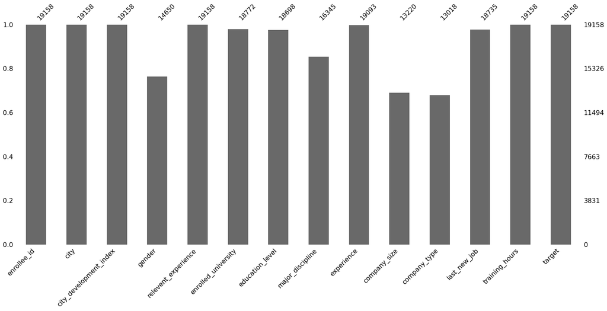

```python
msno.bar(df)
```

```python
# Calculate the percentage of missing values in each column
missing_percentage = df.isnull().mean() * 100

# Display results as a table
print(missing_percentage)
```

```
enrollee_id                0.000000
city                       0.000000
city_development_index     0.000000
gender                    23.530640
relevent_experience        0.000000
enrolled_university        2.014824
education_level            2.401086
major_discipline          14.683161
experience                 0.339284
company_size              30.994885
company_type              32.049274
last_new_job               2.207955
training_hours             0.000000
target                     0.000000
dtype: float64
```

```python
#count number of duplicated rows
df.duplicated().sum()
```

```
0
```

there are no duplicate lines! so nothing to remove

```python
# Returns a dataframe filled with boolean values with true indicating missing values
df.isna( )
```

|  | enrollee_id | city | city_development_index | gender | relevent_experience | enrolled_university | education_level | major_discipline | experience | company_size | company_type | last_new_job | training_hours | target |
| --- | --- | --- | --- | --- | --- | --- | --- | --- | --- | --- | --- | --- | --- | --- |
| 0 | False | False | False | False | False | False | False | False | False | True | True | False | False | False |
| 1 | False | False | False | False | False | False | False | False | False | False | False | False | False | False |
| 2 | False | False | False | True | False | False | False | False | False | True | True | False | False | False |
| 3 | False | False | False | True | False | True | False | False | False | True | False | False | False | False |
| 4 | False | False | False | False | False | False | False | False | False | False | False | False | False | False |
| ... | ... | ... | ... | ... | ... | ... | ... | ... | ... | ... | ... | ... | ... | ... |
| 19153 | False | False | False | False | False | False | False | False | False | True | True | False | False | False |
| 19154 | False | False | False | False | False | False | False | False | False | True | True | False | False | False |
| 19155 | False | False | False | False | False | False | False | False | False | False | False | False | False | False |
| 19156 | False | False | False | False | False | False | False | True | False | False | False | False | False | False |
| 19157 | False | False | False | True | False | False | False | True | False | True | True | False | False | False |

19158 rows × 14 columns

```python
df.corr()
```

|  | enrollee_id | city_development_index | training_hours | target |
| --- | --- | --- | --- | --- |
| enrollee_id | 1.000000 | -0.040455 | 0.000998 | 0.049475 |
| city_development_index | -0.040455 | 1.000000 | 0.001920 | -0.341665 |
| training_hours | 0.000998 | 0.001920 | 1.000000 | -0.021577 |
| target | 0.049475 | -0.341665 | -0.021577 | 1.000000 |

# Data Visulaisation

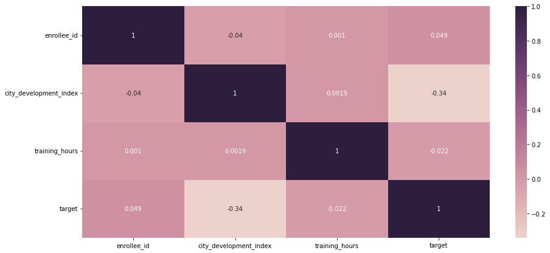

```python
plt.figure(figsize=(15,7))
sns.heatmap(df.corr(),annot=True,cmap=sns.cubehelix_palette(as_cmap=True))
plt.show()
```

```
array([[<AxesSubplot:title={'center':'enrollee_id'}>,
        <AxesSubplot:title={'center':'city_development_index'}>],
       [<AxesSubplot:title={'center':'training_hours'}>,
        <AxesSubplot:title={'center':'target'}>]], dtype=object)
```

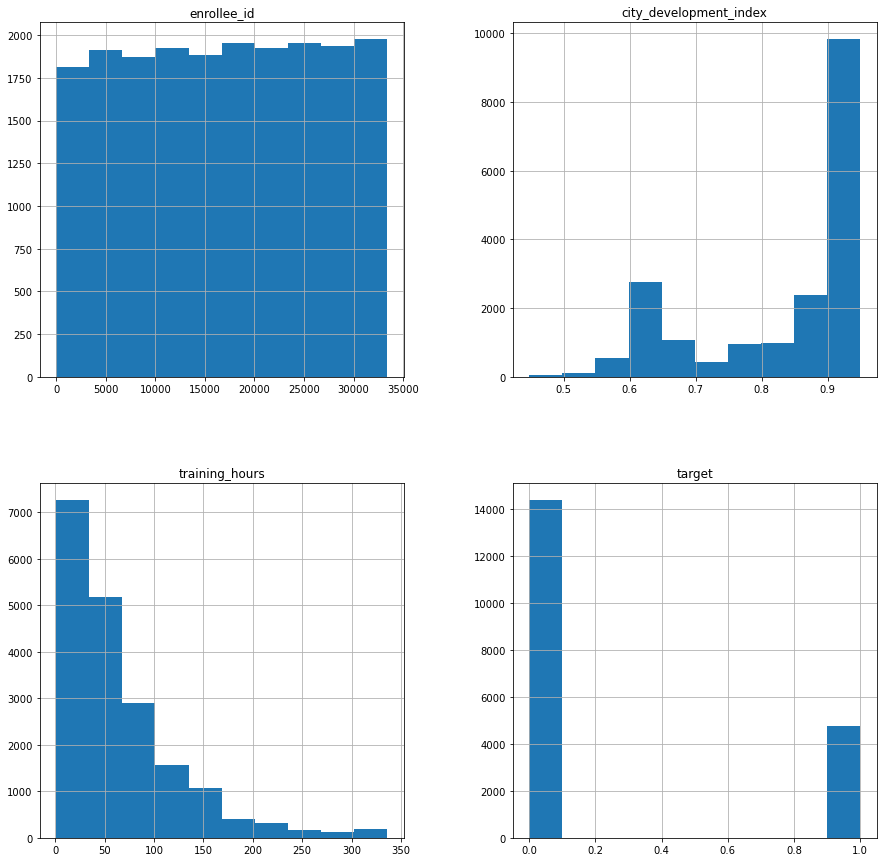

```python
df.hist(figsize=(15,15))
```

### Variables :

```python
#gender:
```

```python
# Return number of unique elements in the object
df.nunique()
df['gender'].unique()
```

```
array(['Male', nan, 'Female', 'Other'], dtype=object)
```

```
Male      90.245734
Female     8.450512
Other      1.303754
Name: gender, dtype: float64
Pourcentage de valeurs manquantes dans la gender: 23.530639941538784 %
```

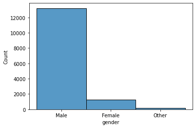

```python
sns.histplot(df["gender"])
# count the number of occurrences of each variable in gender
counts = df['gender'].value_counts()
# calculate the percentage of each variable
pourcentages = counts / counts.sum() * 100
# show percentages
print(pourcentages)
# calculate the percentage of missing values in gender
missing_percent = df['gender'].isna().mean() * 100
# show percentage of missing values
print("Pourcentage de valeurs manquantes dans la gender:", missing_percent, "%")
```

we have a significant percentage of 23.5% of missing values in the gender column. also we have the category "Male" represents 90.25% which is by far the most frequent, "Female" represents 8.45%, and "Other" represents 1.30%.

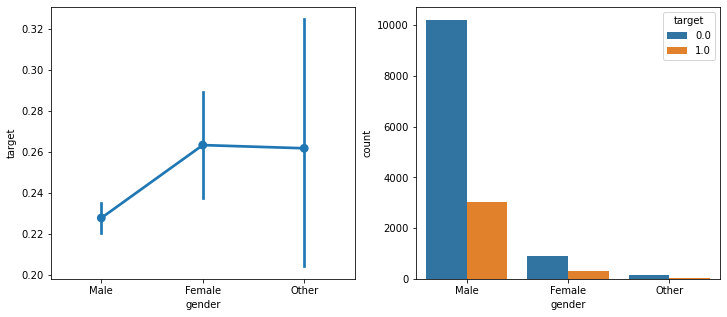

```python
fig,(ax1,ax2)=plt.subplots(1,2,figsize=(12,5))
# show the relationship between the "gender" variable and the "target" variable
sns.pointplot(data=df,x="gender",y="target",ax=ax1)
#show the count of "gender" variable for aech value of the "target"
sns.countplot(data=df,x="gender",hue="target",ax=ax2)
```

The first graph is a pointplot that shows the relationship between the "gender" variable and the "target" variable. It shows the average of the "target" variable for each value of the "gender" variable. the line connecting the points male and female has an upward slope, this suggests that higher values of "gender" are associated with higher values of "target". also the line connecting the points female and other is almost horizontal, this suggests that there is no clear linear relationship between the two variables. The second graph is a countplot that shows the number of times each "gender" value occurs for each "target" value. It uses the hue function to separate the bars for each "target" value. the bars for each value of "gender" are of a strong size for each value of "target", this suggests that there is not a strong correlation between the two variables.

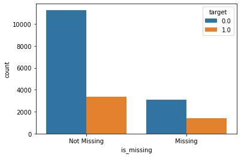

```python
df['is_missing'] = df['gender'].isnull()
# Plot the distribution of the target variable based on whether a value is missing or not
sns.countplot(x='is_missing', hue='target', data=df)
plt.xticks([0, 1], ['Not Missing', 'Missing'])
plt.legend(title='target')
plt.show()
```

This result suggests that there is no significant relationship between the "gender" variable and the "target" variable, I have observed that the number of missing gender data is higher in the target 0 group compared to the target 1 group. Therefore, it is likely that the missing "gender" variable has no significant effect on the "target" variable.

```python
df.groupby("target")["gender"].value_counts()
```

```
target  gender
0.0     Male      10209
        Female      912
        Other       141
1.0     Male       3012
        Female      326
        Other        50
Name: gender, dtype: int64
```

we see: target gender 0.0 Male 10209 Female 912 Other 141 1.0 Male 3012 Female 326 Other 50Based on my analysis, I recommend replacing the missing values in this dataset with either the most frequent value, which is 'male', or with a specified value. This will ensure that the dataset is complete and can be used for further analysis.

```python
#enrolled_university
```

```python
# Return number of unique elements in the object
df.nunique()
df['enrolled_university'].unique()
```

```
array(['no_enrollment', 'Full time course', nan, 'Part time course'],
      dtype=object)
```

```
no_enrollment       73.604304
Full time course    20.013850
Part time course     6.381845
Name: enrolled_university, dtype: float64
Pourcentage de valeurs manquantes dans l'enrolled_university: 2.0148240943731075 %
```

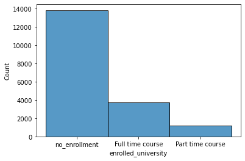

```python
sns.histplot(df["enrolled_university"])
# count the number of occurrences of each variable in enrolled_university
counts = df['enrolled_university'].value_counts()
# calculate the percentage of each variable
pourcentages = counts / counts.sum() * 100
# show percentages
print(pourcentages)
# calculate the percentage of missing values in enrolled_university
missing_percent = df['enrolled_university'].isna().mean() * 100
# show percentage of missing values
print("Pourcentage de valeurs manquantes dans l'enrolled_university:", missing_percent, "%")
```

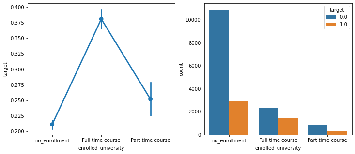

```python
fig,(ax1,ax2)=plt.subplots(1,2,figsize=(12,5))
# show the relationship between the "enrolled_university" variable and the "target" variable
sns.pointplot(data=df,x="enrolled_university",y="target",ax=ax1)
#show the count of "enrolled_university" variable for aech value of the "target"
sns.countplot(data=df,x="enrolled_university",hue="target",ax=ax2)
```

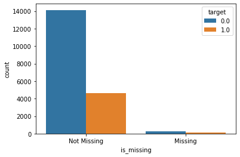

```python
df['is_missing'] = df['enrolled_university'].isnull()
# Plot the distribution of the target variable based on whether a value is missing or not
sns.countplot(x='is_missing', hue='target', data=df)
plt.xticks([0, 1], ['Not Missing', 'Missing'])
plt.legend(title='target')
plt.show()
```

```python
df.groupby("target")["enrolled_university"].value_counts()
```

```
target  enrolled_university
0.0     no_enrollment          10896
        Full time course        2326
        Part time course         896
1.0     no_enrollment           2921
        Full time course        1431
        Part time course         302
Name: enrolled_university, dtype: int64
```

Based on my analysis, I decided to use onther name for the missing values in enrolled_university for make it clearer .

```python
# education_level
```

```python
# Return number of unique elements in the object
df.nunique()
df['education_level'].unique()
```

```
array(['Graduate', 'Masters', 'High School', nan, 'Phd', 'Primary School'],
      dtype=object)
```

```
Graduate          62.028024
Masters           23.323350
High School       10.787250
Phd                2.214141
Primary School     1.647235
Name: education_level, dtype: float64
Pourcentage de valeurs manquantes dans la education_level: 2.401085708320284 %
```

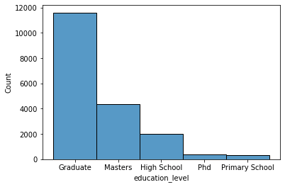

```python
# education_level
sns.histplot(df["education_level"])
# count the number of occurrences of each variable in education_level
counts = df['education_level'].value_counts()
# calculate the percentage of each variable
pourcentages = counts / counts.sum() * 100
# show percentages
print(pourcentages)
# calculate the percentage of missing values in education_level
missing_percent = df['education_level'].isna().mean() * 100

# show percentage of missing values
print("Pourcentage de valeurs manquantes dans la education_level:", missing_percent, "%")
```

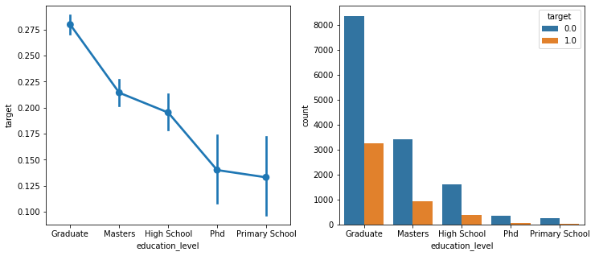

```python
fig,(ax1,ax2)=plt.subplots(1,2,figsize=(12,5))
# show the relationship between the "education_level" variable and the "target" variable
sns.pointplot(data=df,x="education_level",y="target",ax=ax1)
#show the count of "education_level" variable for aech value of the "target"
sns.countplot(data=df,x="education_level",hue="target",ax=ax2)
```

I have observed that individuals with a graduate education level tend to have the highest count for target value '0'. Similarly, those with a masters education level tend to have a count of more than 3000 for target value '0'."

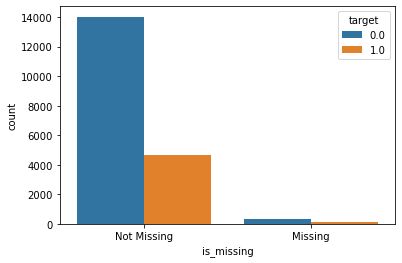

```python
df['is_missing'] = df['education_level'].isnull()
# Plot the distribution of the target variable based on whether a value is missing or not
sns.countplot(x='is_missing', hue='target', data=df)
plt.xticks([0, 1], ['Not Missing', 'Missing'])
plt.legend(title='target')
plt.show()
```

```python
#major_discipline
```

```python
# Return number of unique elements in the object
df.nunique()
df['major_discipline'].unique()
```

```
array(['STEM', 'Business Degree', nan, 'Arts', 'Humanities', 'No Major',
       'Other'], dtype=object)
```

```
STEM               88.663200
Humanities          4.092995
Other               2.330988
Business Degree     2.000612
Arts                1.547874
No Major            1.364332
Name: major_discipline, dtype: float64
Pourcentage de valeurs manquantes dans la major_discipline: 14.68316108153252 %
```

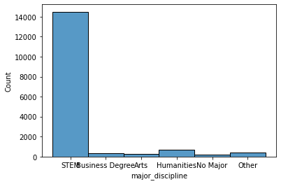

```python
sns.histplot(df["major_discipline"])
# count the number of occurrences of each variable in major_discipline
counts = df['major_discipline'].value_counts()
# calculate the percentage of each variable
pourcentages = counts / counts.sum() * 100
# show percentages
print(pourcentages)
# calculate the percentage of missing values in major_discipline
missing_percent = df['major_discipline'].isna().mean() * 100

# show percentage of missing values
print("Pourcentage de valeurs manquantes dans la major_discipline:", missing_percent, "%")
```

we have a significant percentage of 14.68% of missing values in the major_discipline column. also we have the category "STEM" represents 88.66% which is by far the most frequent, "Humanities" represents 4.09%..

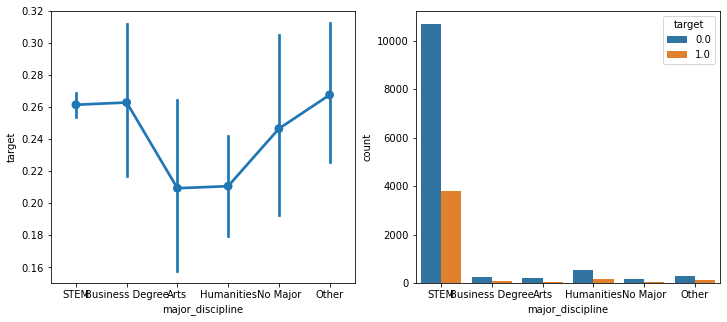

```python
fig,(ax1,ax2)=plt.subplots(1,2,figsize=(12,5))
# show the relationship between the "major_discipline" variable and the "target" variable
sns.pointplot(data=df,x="major_discipline",y="target",ax=ax1)
#show the count of "major_discipline" variable for aech value of the "target"
sns.countplot(data=df,x="major_discipline",hue="target",ax=ax2)
```

I have observed that individuals with STEM education major discipline tend to have the highest count for target value '0'.

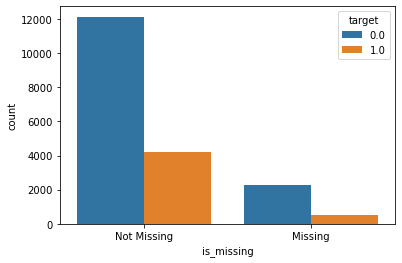

```python
df['is_missing'] = df['major_discipline'].isnull()
# Plot the distribution of the target variable based on whether a value is missing or not
sns.countplot(x='is_missing', hue='target', data=df)
plt.xticks([0, 1], ['Not Missing', 'Missing'])
plt.legend(title='target')
plt.show()
```

I have observed that the number of missing data is very higher in the target 0 group compared to the target 1 group.I chose the mode to replace the missing data in the variable 'major_discipline' because it is a categorical variable with a limited number of possible values. Also, the mode represents the most frequently occurring value, which is likely to be the best estimate for the missing values in this case.

```python
#experience
```

```python
# Return number of unique elements in the object
df.nunique()
df['experience'].unique()
```

```
array(['>20', '15', '5', '<1', '11', '13', '7', '17', '2', '16', '1', '4',
       '10', '14', '18', '19', '12', '3', '6', '9', '8', '20', nan],
      dtype=object)
```

```
>20    17.210496
5       7.489656
4       7.348243
3       7.091604
6       6.368826
2       5.902687
7       5.384172
10      5.158959
9       5.132771
8       4.200492
15      3.592940
11      3.477714
14      3.069188
1       2.875399
<1      2.733986
16      2.660661
12      2.587336
13      2.089771
17      1.791232
19      1.592207
18      1.466506
20      0.775153
Name: experience, dtype: float64
Pourcentage de valeurs manquantes dans la experience: 0.33928385008873574 %
```

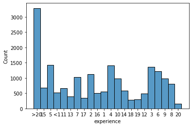

```python
sns.histplot(df["experience"])
# count the number of occurrences of each variable in experience
counts = df['experience'].value_counts()
# calculate the percentage of each variable
pourcentages = counts / counts.sum() * 100
# show percentages
print(pourcentages)
# calculate the percentage of missing values in experience
missing_percent = df['experience'].isna().mean() * 100

# show percentage of missing values
print("Pourcentage de valeurs manquantes dans la experience:", missing_percent, "%")
```

we have a significant percentage of 0.33 of missing values in the experience column. also we have the category ">20" represents 17.21% which is by far the most frequent, "5" represents 7.48%..

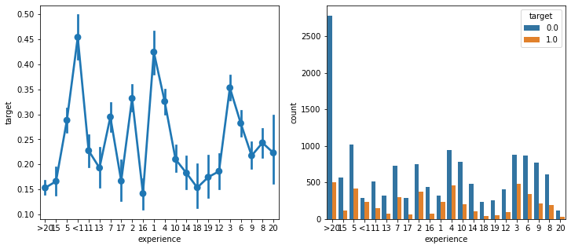

```python
fig,(ax1,ax2)=plt.subplots(1,2,figsize=(12,5))
# show the relationship between the "experience" variable and the "target" variable
sns.pointplot(data=df,x="experience",y="target",ax=ax1)
#show the count of "experience" variable for aech value of the "target"
sns.countplot(data=df,x="experience",hue="target",ax=ax2)
```

I have observed that individuals with >20 EXPERIENCE tend to have the highest count for target value '0'.

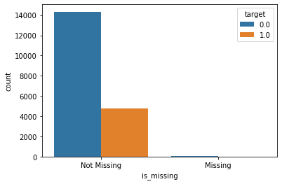

```python
df['is_missing'] = df['experience'].isnull()
# Plot the distribution of the target variable based on whether a value is missing or not
sns.countplot(x='is_missing', hue='target', data=df)
plt.xticks([0, 1], ['Not Missing', 'Missing'])
plt.legend(title='target')
plt.show()
```

```python
#I have observed that the number of missing data is very higher in the target 0 group compared to the target 1 group.
```

#Based on the information provided, there are approximately 0.33928% of missing values. Therefore, it may be feasible to consider deleting the rows with missing values from the dataset.

```python
#company_size
```

```python
# Return number of unique elements in the object
df.nunique()
df['company_size'].unique()
```

```
array([nan, '50-99', '<10', '10000+', '5000-9999', '1000-4999', '10/49',
       '100-500', '500-999'], dtype=object)
```

```
50-99        23.320726
100-500      19.447806
10000+       15.272315
10/49        11.127080
1000-4999    10.045386
<10           9.894100
500-999       6.633888
5000-9999     4.258699
Name: company_size, dtype: float64
Pourcentage de valeurs manquantes dans la company_size: 30.994884643490973 %
```

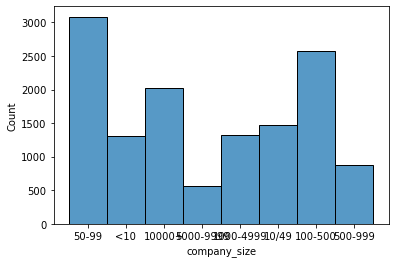

```python
sns.histplot(df["company_size"])
# count the number of occurrences of each variable in company_size
counts = df['company_size'].value_counts()
# calculate the percentage of each variable
pourcentages = counts / counts.sum() * 100
# show percentages
print(pourcentages)
# calculate the percentage of missing values in company_size
missing_percent = df['company_size'].isna().mean() * 100

# show percentage of missing values
print("Pourcentage de valeurs manquantes dans la company_size:", missing_percent, "%")
```

we have a significant percentage of 30.99% of missing values in the company_size column. also we have the category "50-99 " represents 23.32% which is by far the most frequent, "100-500 " represents 19.44%..

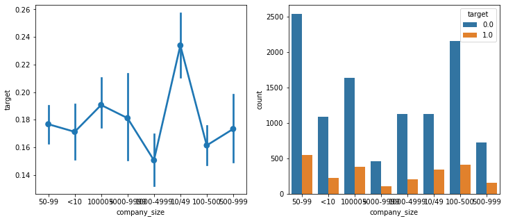

```python
fig,(ax1,ax2)=plt.subplots(1,2,figsize=(12,5))
# show the relationship between the "company_size" variable and the "target" variable
sns.pointplot(data=df,x="company_size",y="target",ax=ax1)
#show the count of "company_size" variable for aech value of the "target"
sns.countplot(data=df,x="company_size",hue="target",ax=ax2)
```

I have observed that individuals with 50-99 company_size tend to have the highest count for target value '0'.

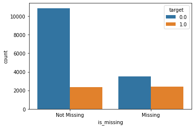

```python
df['is_missing'] = df['company_size'].isnull()
# Plot the distribution of the target variable based on whether a value is missing or not
sns.countplot(x='is_missing', hue='target', data=df)
plt.xticks([0, 1], ['Not Missing', 'Missing'])
plt.legend(title='target')
plt.show()
```

I have observed that the number of missing data is very higher in the target 0 group compared to the target 1 group.For this feature, I have chosen to replace the missing data with the frequent value.

```python
#company_type
```

```python
# Return number of unique elements in the object
df.nunique()
df['company_type'].unique()
```

```
array([nan, 'Pvt Ltd', 'Funded Startup', 'Early Stage Startup', 'Other',
       'Public Sector', 'NGO'], dtype=object)
```

```
Pvt Ltd                75.410969
Funded Startup          7.689353
Public Sector           7.335996
Early Stage Startup     4.632048
NGO                     4.002151
Other                   0.929482
Name: company_type, dtype: float64
Pourcentage de valeurs manquantes dans la company_type: 32.04927445453596 %
```

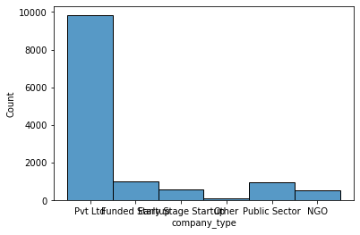

```python
df = pd.read_csv("aug_train.csv")
sns.histplot(df["company_type"])
# count the number of occurrences of each variable in company_type
counts = df['company_type'].value_counts()
# calculate the percentage of each variable
pourcentages = counts / counts.sum() * 100
# show percentages
print(pourcentages)
# calculate the percentage of missing values in company_size
missing_percent = df['company_type'].isna().mean() * 100

# show percentage of missing values
print("Pourcentage de valeurs manquantes dans la company_type:", missing_percent, "%")
```

we have a significant percentage of 32.04% of missing values in the company_type column. also we have the category "Pvt Ltd " represents 75.41% which is by far the most frequent, "Funded Startup " represents 7.68%..

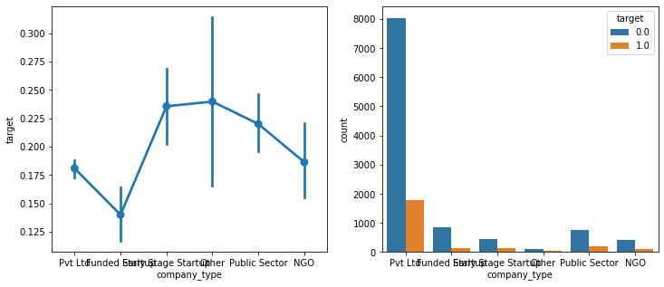

```python
fig,(ax1,ax2)=plt.subplots(1,2,figsize=(12,5))
# show the relationship between the "company_type" variable and the "target" variable
sns.pointplot(data=df,x="company_type",y="target",ax=ax1)
#show the count of "company_type" variable for aech value of the "target"
sns.countplot(data=df,x="company_type",hue="target",ax=ax2)
```

I have observed that individuals with Pvt Ltd company_type tend to have the highest count for target value '0'.

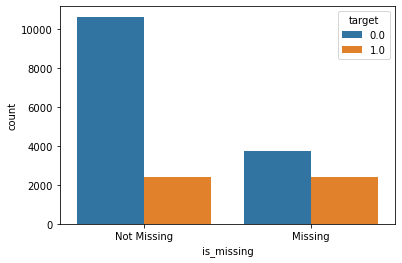

```python
df = pd.read_csv("aug_train.csv")
df['is_missing'] = df['company_type'].isnull()
# Plot the distribution of the target variable based on whether a value is missing or not
sns.countplot(x='is_missing', hue='target', data=df)
plt.xticks([0, 1], ['Not Missing', 'Missing'])
plt.legend(title='target')
plt.show()
```

```python
#I have observed that the number of missing data is very higher in the target 0 group compared to the target 1 group.
```

```python
#last_new_job
```

```python
# Return number of unique elements in the object
df = pd.read_csv("aug_train.csv")
df.nunique()
df['last_new_job'].unique()
```

```
array(['1', '>4', 'never', '4', '3', '2', nan], dtype=object)
```

```
1        42.914331
>4       17.560715
2        15.479050
never    13.087804
4         5.492394
3         5.465706
Name: last_new_job, dtype: float64
Pourcentage de valeurs manquantes dans la last_new_job: 2.207954901346696 %
```

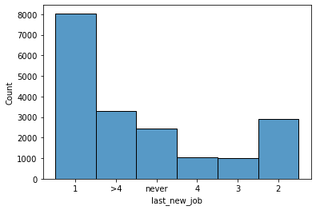

```python
df = pd.read_csv("aug_train.csv")
sns.histplot(df["last_new_job"])
# count the number of occurrences of each variable in last_new_job
counts = df['last_new_job'].value_counts()
# calculate the percentage of each variable
pourcentages = counts / counts.sum() * 100
# show percentages
print(pourcentages)
# calculate the percentage of missing values in last_new_job
missing_percent = df['last_new_job'].isna().mean() * 100

# show percentage of missing values
print("Pourcentage de valeurs manquantes dans la last_new_job:", missing_percent, "%")
```

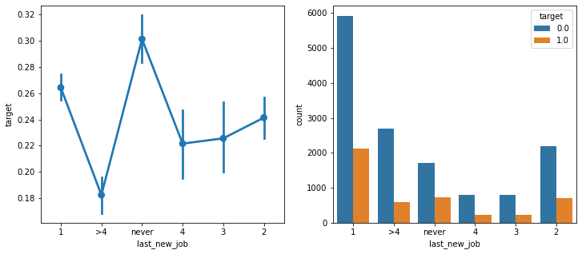

```python
fig,(ax1,ax2)=plt.subplots(1,2,figsize=(12,5))
# show the relationship between the "last_new_job" variable and the "target" variable
sns.pointplot(data=df,x="last_new_job",y="target",ax=ax1)
#show the count of "last_new_job" variable for aech value of the "target"
sns.countplot(data=df,x="last_new_job",hue="target",ax=ax2)
```

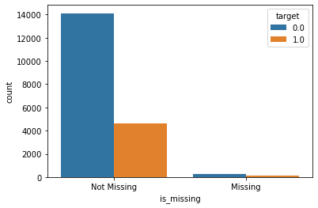

```python
df = pd.read_csv("aug_train.csv")
df['is_missing'] = df['last_new_job'].isnull()
# Plot the distribution of the target variable based on whether a value is missing or not
sns.countplot(x='is_missing', hue='target', data=df)
plt.xticks([0, 1], ['Not Missing', 'Missing'])
plt.legend(title='target')
plt.show()
```

I have observed that the number of missing data is very higher in the target 0 group compared to the target 1 group.For this feature, I have chosen to replace the missing data with the frequent value.